# What kind of median earnngs to expect from a type of major

Kelly Trinh, Hanfei Sun, and Nathan Lam

### Introduction

Not all college students are informed about how the choice of their major can impact their earnings after graduation. We aim to provide an overview for college students of the financial standing of graduates from different majors categories. Our research question is:

**Given a major category, what’s likely to be my median income as a full-time, year-round worker?**

We will be building an OLS model to explain the association between major category and median income; and to predict the median income given a major category.

#### Dataset

The dataset we use is the recent-grad dataset from fivethirtyeight. https://www.rdocumentation.org/packages/fivethirtyeight/versions/0.6.1/topics/college_recent_grads

It contains income and other information about 16 different major categories. Below is a detailed description of each variable:

| Header | Description |
| --- | --- |
| `Rank` | Rank by median earnings |
| `Major_code` | Major code |
| `Major` | Major description |
| `Major_category` | Category of major |
| `Total` | Total number of people with major |
| `Sample_size` | Sample size of full-time, year-round |
| `Men` | Male graduates |
| `Women` | Female graduates |
| `ShareWomen` | Women as share of total |
| `Employed` | Number employed |
| `Full_time` | Employed 35 hours or more |
| `Part_time` | Employed less than 35 hours |
| `Full_time_year_round` | Employed at least 50 weeks and at least 35 hours |
| `Unemployed` | Number unemployed |
| `Unemployment_rate` | Unemployed / (Unemployed + Employed) |
| `Median` | Median earnings of full-time, year-round workers |
| `P25th` | 25th percentile of earnings |
| `P75th` | 75th percentile of earnings |
| `College_jobs` | Number with job requiring a college degree |
| `Non_college_jobs` | Number with job not requiring a college degree |
| `Low_wage_jobs` | Number in low-wage service jobs |

### EDA and data cleaning

Here are some modifications we did to our data:

1. The target variable `median` is right-skewed, so we log transformed it.
2. There is only one row with missing variables, so we omitted the row.
3. When examining the correlation plots, we see that many variables are highly correlated. For example, `college_jobs`, `employed_fulltime`, `employed_parttime` are highly correlated. We created new variables based on these highly correlated variables into `college_job_prop` and `full_time_yearround_prop`, which gives the proportions rather than an absolute number. We believe these variables would be less correlated with other explanatory variables.
4. We standardized continuous variables to prepare for variable selection and transformed categorical variables into dummies.
5. We also performed a 80-20 test-train split; the test set will be used to detect overfitting and to build prediction intervals.

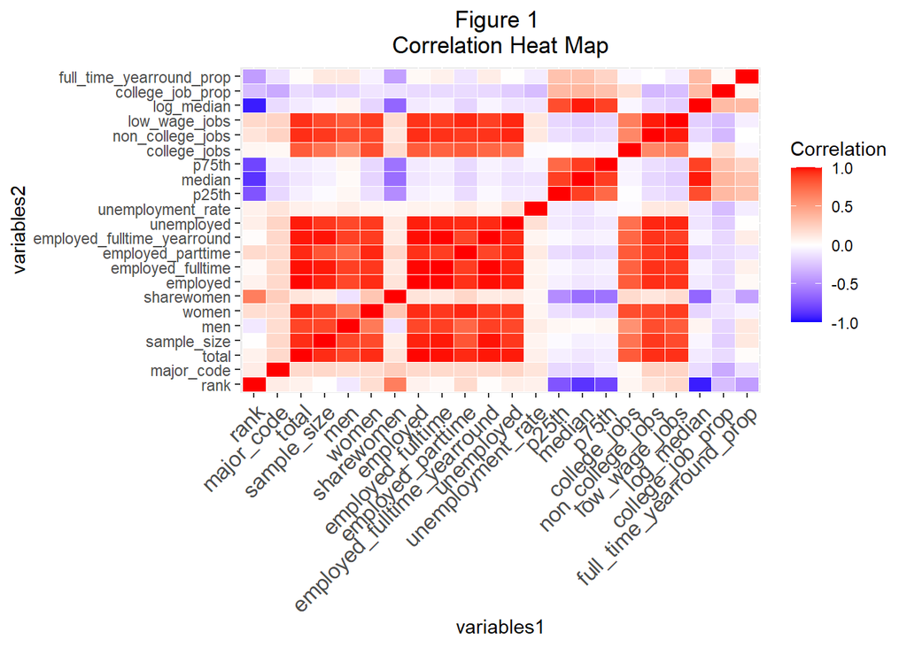

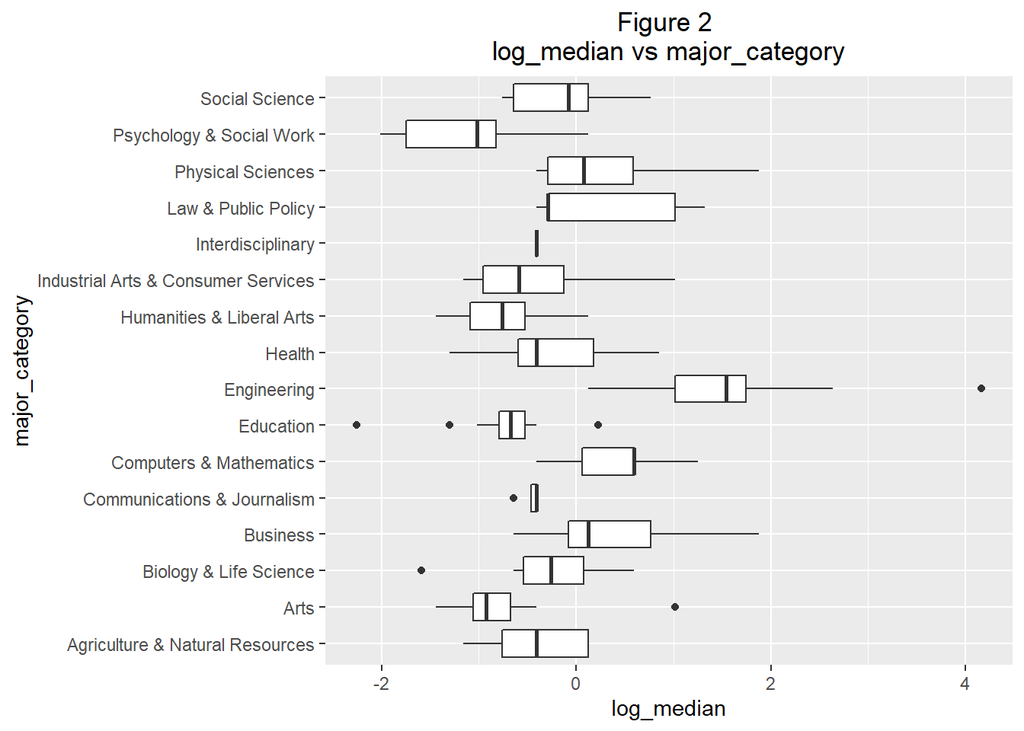

Using the alias function on a lm object with all variables reveals which variables are collinear, this turned out to be the variables total and men. We removed men as well as the variables major_code, p25th, and p75th as they do not benefit the model.

### Model selection

#### Methodology

We used backward and forward selection to filter out the existing variables; we consider interaction terms later. We produced six models: the 3 best models selected by backward selection in terms of Mallow’s Cp, BIC, and adjusted R squared; and the 3 best models selected by forward selection using the same criterias. To decide between the 6 models, we performed leave-one-out cross validation (LOOCV) and calculated the root mean squared error (RMSE). We select the model with the lowest LOOCV RMSE, which is the model selected using backward selection with adjusted R squared as a criteria (this selected model is the same model chosen from backward selection using Mallow’s Cp). The selected model without interaction terms has RMSE of `0.2435908`. We ensure to check for overfitting by training the selected model using the training set, predict on the testing set, and look at the sum of error squared and the correlation between the fitted values and the actual values.

Next, we consider adding interaction terms. We used the Analysis of Variance test to determine which interaction terms to add to the model. To compare this model and the model without interaction terms, we again calculate the LOOCV RMSE for the former and compare with the RMSE of the latter. We found that the model with interaction terms perform better; specficially its LOOCV RMSE is `0.1933749`.

The two methods of variable selection (backward/forward versus Analysis of Variance) each have their weaknesses. Backward/forward selection add variable step-wise, so this method doesn’t guarantee to select the best subset of explanatory variables; furthermore, it doesn’t obey the principle of marginality and doesn’t treat the variable `major_category` as a single category. Nevertheless, it doesn’t rely on the assumption that the explanatory variable is normally distributed, while the Analysis of Variance test does. The Analysis of Variance test does obey the principle of marginality, and hence is better suited to select interaction terms. Due to these weaknesses, the model we selected didn’t include all of the original 16 `major_category`, but only `Computers & Mathematics`, `Engineering`, and `Biology & Life Science`, which encompasses 31% of all the majors listed in our dataset. Our model selection method has made the `major_category` variables coarser.

#### Variable selection without interactions: backward/forward/cross-validation

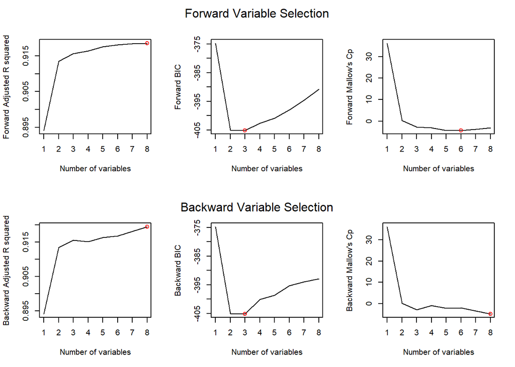

```
## Sum of Errors Squared:  3.161369
```

```
## Correlation between the predicted values and actual values:  0.912199
```

Summary table description:

`forward.rmse` and `backward.rmse` are columns with the RMSE from prediction on the testing dataset depending on either forward selection or backward selection. Each of the row represent the criteria in which to choose the model from either forward or backward selection: `Adjusted R squared`, `BIC`, `Mallow's Cp`.

| criterias | forward.rmse | backward.rmse |
| --- | --- | --- |
| Adjusted R squared | 0.2464696 | 0.2435908 |
| BIC | 0.2484253 | 0.2484253 |
| Mallow's Cp | 0.2476821 | 0.2435908 |

#### Variable selection with interactions

To examine possible interaction terms, we look at coplots, created on the training data set with standardized continuous variables. The coplots show that `sharewomen` and `employed_fulltime_yearround` seem to have interactions with `major_category`. However, these coplots are inconclusive, so we will run an Analysis of Variance test to determine which interaction terms to keep.

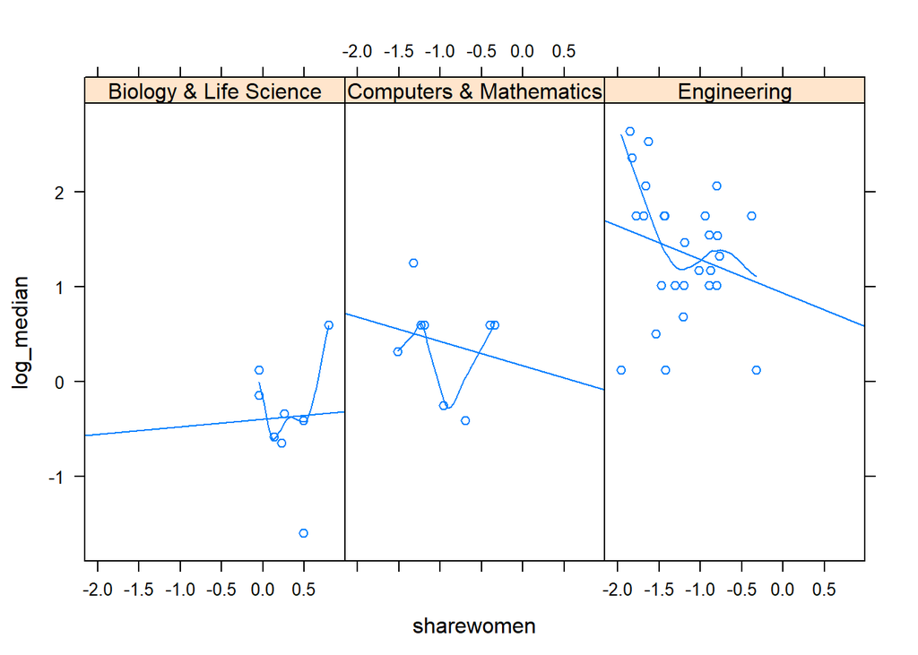

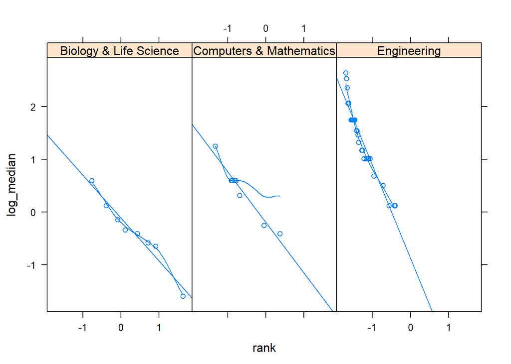

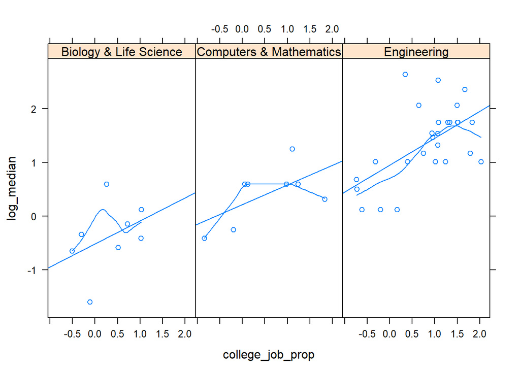

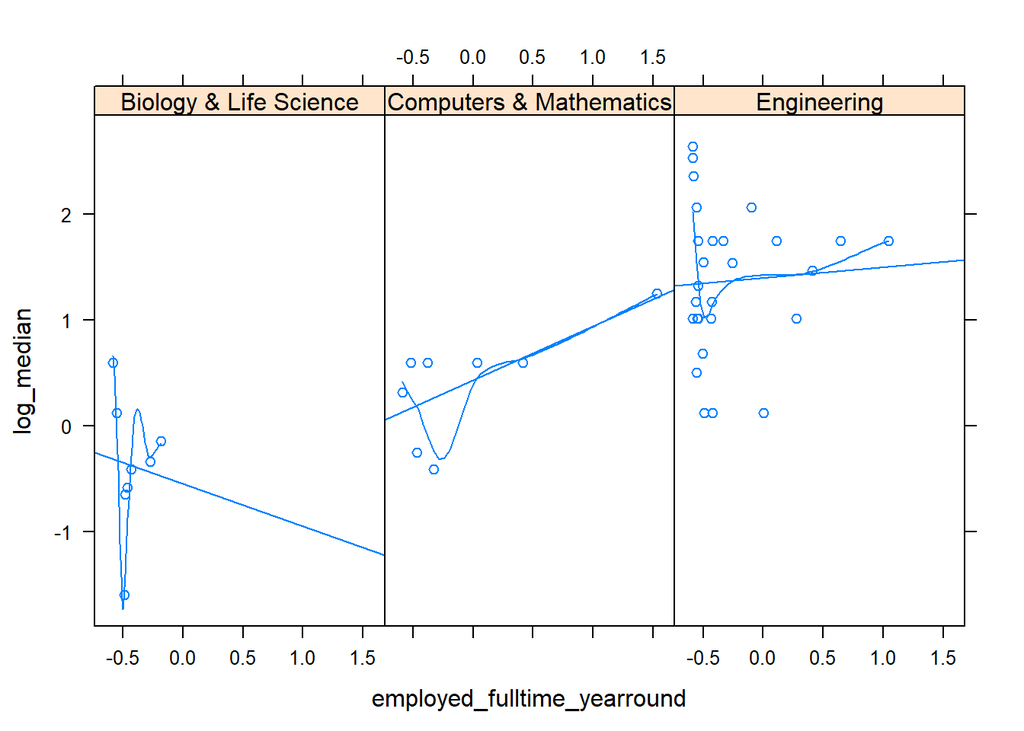

We will keep all the original terms (not interaction terms) and will use the Analysis of Variance test to determine which interaction terms to add. This test, unlike the coplots shown above, show that interaction terms `rank:major_category_Engineering` and `sharewomen:major_category_Engineering` have significant p-values. We will include those variables in our final selected model.

#### Results

After considering the interaction terms, the selected model we chose includes the following variables: `rank`,`sharewomen`,`employed`, `employed_fulltime_yearround`, `college_job_prop`, `major_category_Biology...Life.Science`, `major_category_Computers...Mathematics`, `major_category_Engineering`, `major_category_Engineering * rank`, and `major_category_Engineering * sharewomen`.

### Diagnostics

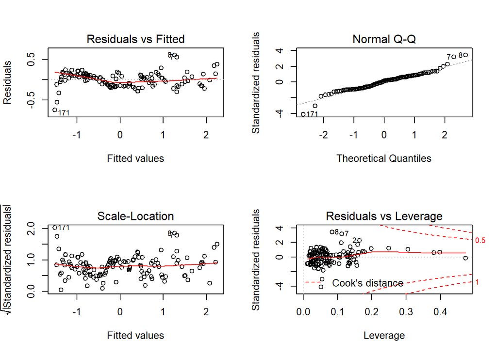

|  | rank | major_code | total | sample_size | men | women | sharewomen | employed | employed_fulltime | employed_parttime | employed_fulltime_yearround | unemployed | unemployment_rate | p25th | median | p75th | college_jobs | non_college_jobs | low_wage_jobs | log_median | college_job_prop | full_time_yearround_prop | major_category_Arts | major_category_Biology...Life.Science | major_category_Business | major_category_Communications...Journalism | major_category_Computers...Mathematics | major_category_Education | major_category_Engineering | … |
| --- | --- | --- | --- | --- | --- | --- | --- | --- | --- | --- | --- | --- | --- | --- | --- | --- | --- | --- | --- | --- | --- | --- | --- | --- | --- | --- | --- | --- | --- | --- |
| 171 | 1.706801 | -0.2348409 | -0.6053869 | -0.5765977 | -0.5922209 | -0.5302517 | 1.54429216 | -0.6054164 | -0.5977496 | -0.5910490 | -0.5858389 | -0.5704201 | 1.2184726 | -1.0264879 | -1.572607 | -1.976691 | -0.5691383 | -0.5481298 | -0.5318373 | -2.258713 | -0.2415388 | -0.7405737 | 0 | 0 | 0 | 0 | 0 | 1 | 0 | … |
| 7 | -1.605289 | 1.3689298 | -0.5632631 | -0.4976805 | -0.5220905 | -0.5131642 | -0.36746826 | -0.5627582 | -0.5435864 | -0.5870371 | -0.5236024 | -0.5169041 | 0.9084334 | 2.5674138 | 1.907152 | 1.378954 | -0.4999356 | -0.5491344 | -0.5222309 | 1.875002 | 1.7220499 | 2.2813363 | 0 | 0 | 1 | 0 | 0 | 0 | 0 | … |
| 8 | -1.585337 | 0.6558129 | -0.5944746 | -0.5637133 | -0.5674481 | -0.5303489 | 0.04570044 | -0.5900044 | -0.5863175 | -0.5695616 | -0.5733135 | -0.5834963 | -1.5764308 | 0.2259324 | 1.907152 | 3.862131 | -0.5371554 | -0.5413485 | -0.5278227 | 1.875002 | 0.7690312 | -0.8476392 | 0 | 0 | 0 | 0 | 0 | 0 | 0 | … |
| 2 | -1.705051 | -0.8790806 | -0.6107644 | -0.5685450 | -0.5728782 | -0.5518117 | -1.85405393 | -0.6074216 | -0.5986093 | -0.5956048 | -0.5864997 | -0.5709044 | 1.6286645 | 2.7852260 | 3.038074 | 2.586986 | -0.5662393 | -0.5515204 | -0.5521971 | 2.634460 | 0.3465613 | -0.1993523 | 0 | 0 | 0 | 0 | 0 | 0 | 1 | … |

```
## [1] 0.1555571
```

### Prediction

```
##          fit       lwr        upr
## 165 -1.28595 -1.586913 -0.9849877
```

```
##          fit      lwr      upr actual
## 165 28141.92 26099.63 30344.02  27000
```